# Assignment 4

Date: November 22, 2023

Notice:

- Due date: 11:59 p.m., December 6, 2023.
- Please submit your solutions on Canvas.
- Two files are required on submission:
  - A **.pdf** file that includes all the conceptual parts. You may take photos of your handwriting hardcopy and compile them into a **.pdf** file.
  - An **.html**/**.pdf** file automatically generated by **.ipynb/.Rmd** file that includes all the codes and results for the coding part. You will get 0 marks in this part if you do not meet the format requirement.
  - The raw **.ipynb/.Rmd** file is **optional**.
  - Write your code in a modular, readable way. Code organization will be taken into account for the grading.

## Exercises from the reference book

Chapter 8: 3, 4.

**Please ensure you are using the second edition of the book, which can be downloaded [here](https://www.statlearning.com/).**

## Additional coding task

Let's consider a simple regression task with the ground truth $$ y = f(X) + \epsilon, $$ where $f(\cdot)$ is an unknown function, $y \in \mathbb{R}^{N \times 1}$ is the response variable, $X \in \mathbb{R}^{N \times P}$ is the design matrix, $\epsilon \in \mathbb{R}^{N \times 1}$ is the random noise term.

The datasets were generated as follows: first, the design matrix $X \in \mathbb{R}^{500 \times 50}$ was sampled randomly from a uniform distribution. Then the true value $y_0 \in \mathbb{R}^{500 \times 1}$ was generated with the pre-defined function $f(\cdot)$. At last, the noisy observation $y$ was generated with different signal-to-noise ratios (SNR) ($y = y_o + \text{noise}$). The suffixes `high_snr` and `low_snr` distinguish two different situations, high SNR and low SNR. Note that both two situations share the same design matrix $X$. The datasets were split into the training set and the test set randomly.

The data were stored in the `.txt` file. For $X$, each row represents one sample and each column represents one predictor variable.

In this coding task, you are expected to apply the random forest and gradient boosting in these simulated datasets. More importantly, try to compare the performances (mean squared error with respect to the test set) with different SNRs and parameter settings (`mtry` in random forest and `learning rate` in gradient boosting). Specifically, in the high SNR case, you should use `X_train.txt` and `y_train_high_snr.txt` to train the model, then use `X_test.txt` to make predictions for the new data, at last, evaluate the model performance using `y_test_high_snr.txt`. In the low SNR case, you should use `X_train.txt` and `y_train_low_snr.txt` to train the model, then use `X_test.txt` to make predictions for the new data, at last, evaluate the model performance using `y_test_low_snr.txt`.

You are also expected to visualize the results as follows. The first two figures show the performances of the random forest with different `mtry` settings, and the remaining two show the performances of the gradient boosting with different `learning rate` settings. You should figure out which correspond to the high SNR case and which correspond to the low SNR case and make some conclusions about the pattern of the figures. Note that due to other parameter settings and randomness, the errors do not need to be exactly the same as in the figures, but the patterns should be similar.

It's fine to call the `randomForest` and `xgboost` packages directly.

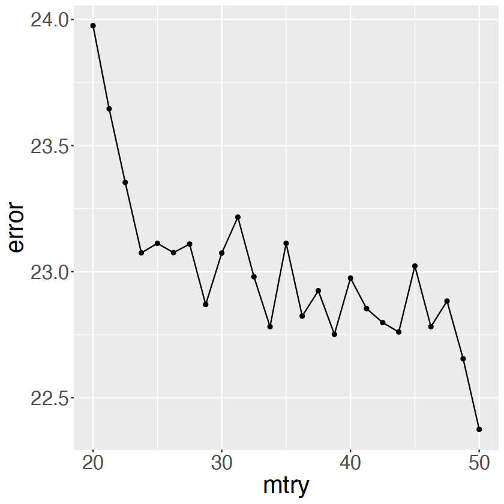

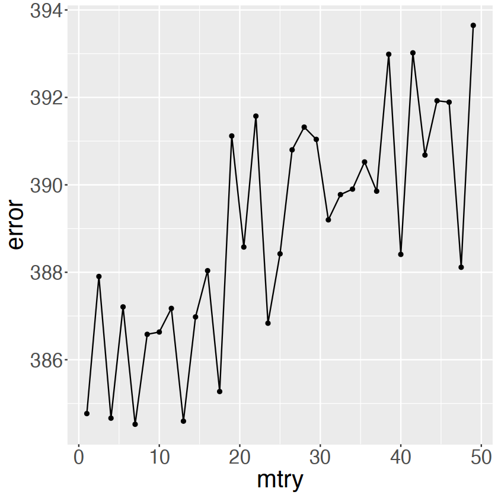

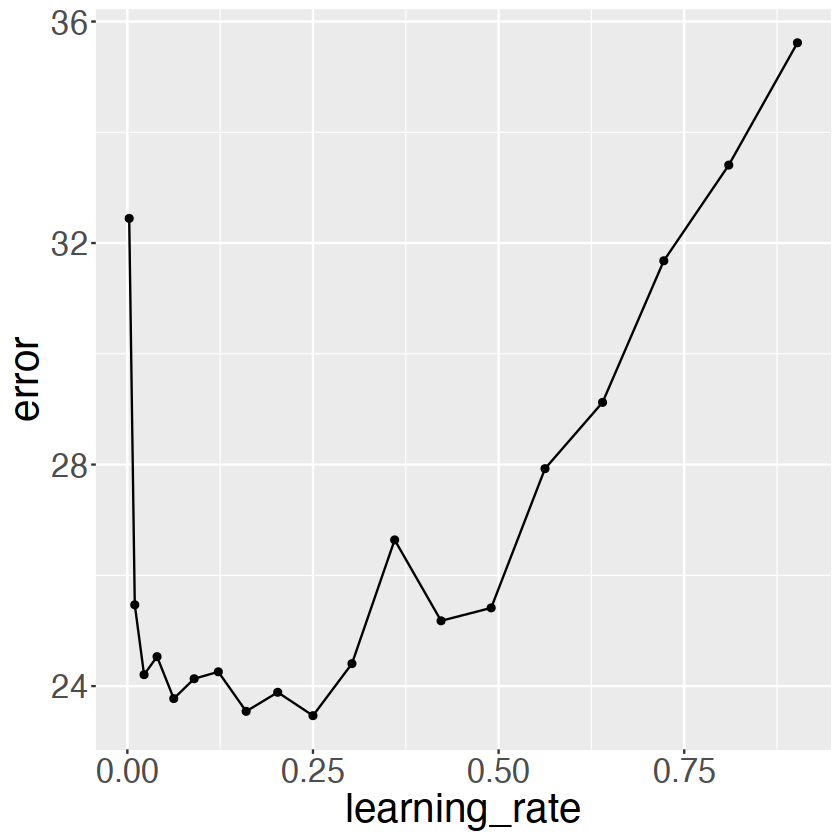

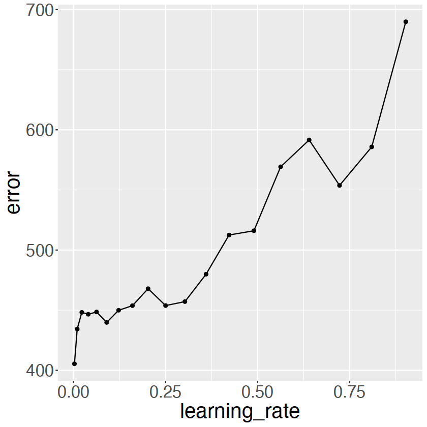